# Final Project on Real Estate Data

Luke Morris

12/16/2019

# 2019: Guest Circle Yearly Report

For this project, I originally picked out some soccer statistics data with the idea of trying to construct a betting model. However, after talking to my father over break about the family business he runs, I had the opportunity to get my hands on two of his messy data sets and test out my skills while providing a tool for my father.

I thought it would be really neat to treat this project like a template to email property owners about how their properties are performing. This being said, my main focus of this project was to clean the data into a glyph friendly fashion. This allows me to graph different variables and use different tools than my father has access to in excel.

## Research Questions of interest

The overarching research question of this project that I am looking to address is, how is the particular property of interest performing in terms of volume of bookings and cancels. I also wanted to address the impacts of different variables like # of children, # of adults, time of year and how it may impact the business and customers.

```r
library(mosaicData)
library(DataComputing)
library(tidyr)
library(devtools)
library(tidyr)
library(dplyr)
library(lubridate)
library(ggplot2)
library(zipcode)
library(lubridate)
```

## How are the properties performing under Bear Mt management?

```r
bmre.payments. <- read.csv("/Users/lukem/Downloads/bmre.payments..csv")


bmre.reservations <- read.csv("/Users/lukem/Downloads/bmre.reservations.csv")

#checking data for red flags

head(bmre.reservations)
```

|  | Reservation.ID | Listing.Number | Property.Name | Created.On | Email | Inquirer | Phone | Check.in | Check.out | Nights.Stay | Adults | Children | Status | Source | X |
| --- | --- | --- | --- | --- | --- | --- | --- | --- | --- | --- | --- | --- | --- | --- | --- |
| 1 | HA-0W6HZQ | 4810284 | Pine Swamp - 45 Guest Circle | 8/17/2019 | osborne7453@comcast.net | Matthew Osborne | +1 (717) 449-3007 | 12/11/2019 | 12/14/2019 | 3 | 5 | 0 | Booked |  |  |
| 2 | HA-WL1ST5 | 7826132 | Morton - 221 Bishop | 10/18/2019 | nataif@yahoo.com | Slava Tatarynov | +1 (917) 306-1759 | 11/15/2019 | 11/17/2019 | 2 | 7 | 2 | Booked |  |  |
| 3 | HA-99C3M8 | 7612953 | Lindbergh Lodge | 11/7/2019 | lejemalik@gmail.com | huda quhshi | +1 (917) 378-8993 | 11/8/2019 | 11/10/2019 | 2 | 4 | 0 | Booked |  |  |
| 4 | HA-XSZR04 | 7465634 | Unni - 471 Pensyl Creek Rd | 11/7/2019 | abasquez214@gmail.com | Angela Basquez |  | 1/10/2020 | 1/12/2020 | 2 | 1 | 0 | Payment Request Sent | Vrbo | Vrbo |
| 5 | HA-C84549 | 7465634 | Unni - 471 Pensyl Creek Rd | 10/10/2019 | yysoong2016@yahoo.com | pengfei lu | +1 (347) 997-2339 | 11/8/2019 | 11/10/2019 | 2 | 4 | 1 | Booked |  |  |
| 6 | HA-GSQY62 | 7426306 | Foulk - 93 Split Rock Road | 11/2/2019 | m_morganti@hotmail.com | MaryEllen Morganti | 1 (203) 668-2944 | 8/8/2020 | 8/15/2020 | 7 | 5 | 4 | Cancelled | Vrbo | Vrbo |

```r
head(bmre.payments.)
```

|  | ï..RefID | Reservation.ID | Check.In | Check.Out | Number.of.Nights | Payment.Date | Disbursement.Date | Payment.Type | Property.ID | Guest.Name | Payment.Method | Taxable.Revenue | Non.Taxable.Revenue | Tax | Service.Fee | Currency | Paid.By.Guest | Your.Revenue | Payment.Processing.Fee | Stay.Tax.We.Remit | Stay.Tax.You.Remit | Deposit.Amount | Payable.To.You |
| --- | --- | --- | --- | --- | --- | --- | --- | --- | --- | --- | --- | --- | --- | --- | --- | --- | --- | --- | --- | --- | --- | --- | --- |
| 1 | 40259099:47 | HA-5Y7HWR | 27-Jul-18 | 29-Jul-18 | 2 | 30-May-18 | 30-Jul-18 | Rent | 4810284 | Kevin Nguyen | Credit Card | $465.00 | $0.00 | $41.85 | $99.00 | USD | $605.85 | $506.85 | ($15.20) | $0.00 | $0.00 | $491.65 | $491.65 |
| 2 | 8774789:167 | HA-PTMM35 | 26-Jun-18 | 30-Jun-18 | 4 | 27-May-18 | 27-Jun-18 | RDD | 4810284 | Abdul Samad | Credit Card | $780.00 | $300.00 | $70.20 | $89.00 | USD | $1,239.20 | $1,150.20 | ($34.50) | $0.00 | $0.00 | $1,115.70 | $1,115.70 |
| 3 | 6377541:105 | HA-95SC34 | 18-May-18 | 20-May-18 | 2 | 27-May-18 | 21-May-18 | Refund (RDD) | 4810284 | Nestor Nazario | Credit Card | $0.00 | $0.00 | $0.00 | $0.00 | USD | ($300.00) | ($300.00) | $9.00 | $0.00 | $0.00 | ($291.00) | ($291.00) |
| 4 | 8765576:167 | HA-T1GKF7 | 15-Jun-18 | 17-Jun-18 | 2 | 26-May-18 | 18-Jun-18 | RDD | 4810284 | Martine Jean-Baptiste | Credit Card | $530.00 | $300.00 | $47.70 | $59.00 | USD | $936.70 | $877.70 | ($26.33) | $0.00 | $0.00 | $851.37 | $851.37 |
| 5 | 8737385:167 | HA-YTX69Z | 22-Jun-18 | 24-Jun-18 | 2 | 23-May-18 | 25-Jun-18 | RDD | 4810284 | Amanda Hackman | Credit Card | $265.00 | $300.00 | $23.85 | $0.00 | USD | $588.85 | $588.85 | ($17.66) | $0.00 | $0.00 | $571.19 | $571.19 |
| 6 | 8703674:167 | HA-DRS8QS | 8-Jun-18 | 10-Jun-18 | 2 | 20-May-18 | 11-Jun-18 | Rent | 4810284 | indranie sundar | Credit Card | $530.00 | $300.00 | $47.70 | $62.00 | USD | $939.70 | $877.70 | ($26.33) | $0.00 | $0.00 | $851.37 | $851.37 |

```r
nrow(bmre.reservations)
```

```
[1] 770
```

```r
nrow(bmre.payments.)
```

```
[1] 208
```

```r
glimpse(bmre.reservations)
```

```
Observations: 770
Variables: 15
$ Reservation.ID <fct> HA-0W6HZQ, HA-WL1ST5, HA-99C3M8, HA-XSZR04, HA-C84549, HA-GSQY62, HA-P6WQJX, HA-BY1KS0, HA-7GH28V, HA-W...
$ Listing.Number <int> 4810284, 7826132, 7612953, 7465634, 7465634, 7426306, 7465634, 7186994, 7186994, 7426306, 7465634, 4810...
$ Property.Name  <fct> Pine Swamp - 45 Guest Circle, Morton - 221 Bishop, Lindbergh Lodge, Unni - 471 Pensyl Creek Rd, Unni - ...
$ Created.On     <fct> 8/17/2019, 10/18/2019, 11/7/2019, 11/7/2019, 10/10/2019, 11/2/2019, 8/19/2019, 11/1/2019, 9/25/2019, 10...
$ Email          <fct> osborne7453@comcast.net, nataif@yahoo.com, lejemalik@gmail.com, abasquez214@gmail.com, yysoong2016@yaho...
$ Inquirer       <fct> Matthew Osborne, Slava Tatarynov, huda quhshi, Angela Basquez, pengfei lu, MaryEllen Morganti, John Ard...
$ Phone          <fct> +1 (717) 449-3007, +1 (917) 306-1759, +1 (917) 378-8993, , +1 (347) 997-2339, 1 (203) 668-2944, +1 (215...
$ Check.in       <fct> 12/11/2019, 11/15/2019, 11/8/2019, 1/10/2020, 11/8/2019, 8/8/2020, 12/12/2019, 11/27/2019, 11/8/2019, 1...
$ Check.out      <fct> 12/14/2019, 11/17/2019, 11/10/2019, 1/12/2020, 11/10/2019, 8/15/2020, 12/14/2019, 11/30/2019, 11/10/201...
$ Nights.Stay    <int> 3, 2, 2, 2, 2, 7, 2, 3, 2, 2, 3, 3, 7, 2, 3, 2, 4, 4, 3, 5, 3, 4, 4, 5, 4, 2, 3, 5, 3, 4, 2, 3, 2, 7, 2...
$ Adults         <int> 5, 7, 4, 1, 4, 5, 3, 12, 10, 8, 2, 6, 6, 6, 4, 8, 4, 8, 2, 6, 9, 2, 10, 10, 3, 2, 3, 4, 5, 3, 6, 14, 6,...
$ Children       <int> 0, 2, 0, 0, 1, 4, 0, 0, 0, 2, 1, 0, 0, 0, 1, 5, 4, 4, 0, 0, 3, 0, 0, 1, 0, 2, 5, 0, 0, 0, 2, 0, 3, 0, 0...
$ Status         <fct> Booked, Booked, Booked, Payment Request Sent, Booked, Cancelled, Booked, Cancelled, Booked, Booked, Boo...
$ Source         <fct> , , , Vrbo, , Vrbo, , Vrbo, , , , , Vrbo, , , Vrbo, , , , , , HomeAway.com, , , , , , , , , , , HomeAwa...
$ X              <fct> , , , Vrbo, , Vrbo, , Vrbo, , , , , Vrbo, , , Vrbo, , , , , , HomeAway.com, , , , , , , , , , , HomeAwa...
```

```r
glimpse(bmre.payments.)
```

```
Observations: 208
Variables: 23
$ ï..RefID               <fct> 40259099:47, 8774789:167, 6377541:105, 8765576:167, 8737385:167, 8703674:167, 6315447:105, 3979...
$ Reservation.ID         <fct> HA-5Y7HWR, HA-PTMM35, HA-95SC34, HA-T1GKF7, HA-YTX69Z, HA-DRS8QS, HA-L5Y3X1, HA-L5Y3X1, HA-YTX6...
$ Check.In               <fct> 27-Jul-18, 26-Jun-18, 18-May-18, 15-Jun-18, 22-Jun-18, 8-Jun-18, 26-Jul-18, 26-Jul-18, 22-Jun-1...
$ Check.Out              <fct> 29-Jul-18, 30-Jun-18, 20-May-18, 17-Jun-18, 24-Jun-18, 10-Jun-18, 29-Jul-18, 29-Jul-18, 24-Jun-...
$ Number.of.Nights       <int> 2, 4, 2, 2, 2, 2, 3, 3, 2, 2, 2, 3, 2, 6, 3, 3, 2, 2, 2, 3, 3, 7, 3, 3, 3, 2, 2, 3, 2, 2, 2, 3,...
$ Payment.Date           <fct> 30-May-18, 27-May-18, 27-May-18, 26-May-18, 23-May-18, 20-May-18, 19-May-18, 17-May-18, 17-May-...
$ Disbursement.Date      <fct> 30-Jul-18, 27-Jun-18, 21-May-18, 18-Jun-18, 25-Jun-18, 11-Jun-18, 27-Jul-18, 27-Jul-18, 25-Jun-...
$ Payment.Type           <fct> Rent, RDD, Refund (RDD), RDD, RDD, Rent, Refund, Rent, Rent, Refund (RDD), RDD, RDD, RDD, Rent,...
$ Property.ID            <int> 4810284, 4810284, 4810284, 4810284, 4810284, 4810284, 4810284, 4810284, 4810284, 4810284, 48102...
$ Guest.Name             <fct> Kevin Nguyen, Abdul Samad, Nestor Nazario, Martine Jean-Baptiste, Amanda Hackman, indranie sund...
$ Payment.Method         <fct> Credit Card, Credit Card, Credit Card, Credit Card, Credit Card, Credit Card, Credit Card, Cred...
$ Taxable.Revenue        <fct> "$465.00 ", "$780.00 ", "$0.00 ", "$530.00 ", "$265.00 ", "$530.00 ", "$0.00 ", "$577.50 ", "$2...
$ Non.Taxable.Revenue    <fct> "$0.00 ", "$300.00 ", "$0.00 ", "$300.00 ", "$300.00 ", "$300.00 ", "$0.00 ", "$0.00 ", "$0.00 ...
$ Tax                    <fct> $41.85 , $70.20 , $0.00 , $47.70 , $23.85 , $47.70 , $0.00 , $51.98 , $23.85 , $0.00 , $38.70 ,...
$ Service.Fee            <fct> $99.00 , $89.00 , $0.00 , $59.00 , $0.00 , $62.00 , $124.00 , $124.00 , $62.00 , $0.00 , $50.00...
$ Currency               <fct> USD, USD, USD, USD, USD, USD, USD, USD, USD, USD, USD, USD, USD, USD, USD, USD, USD, USD, USD, ...
$ Paid.By.Guest          <fct> "$605.85 ", "$1,239.20 ", "($300.00)", "$936.70 ", "$588.85 ", "$939.70 ", "($753.48)", "$753.4...
$ Your.Revenue           <fct> "$506.85 ", "$1,150.20 ", "($300.00)", "$877.70 ", "$588.85 ", "$877.70 ", "($629.48)", "$629.4...
$ Payment.Processing.Fee <fct> ($15.20), ($34.50), $9.00 , ($26.33), ($17.66), ($26.33), $18.88 , ($18.88), ($8.66), $9.00 , (...
$ Stay.Tax.We.Remit      <fct> $0.00 , $0.00 , $0.00 , $0.00 , $0.00 , $0.00 , $0.00 , $0.00 , $0.00 , $0.00 , $0.00 , $0.00 ,...
$ Stay.Tax.You.Remit     <fct> $0.00 , $0.00 , $0.00 , $0.00 , $0.00 , $0.00 , $0.00 , $0.00 , $0.00 , $0.00 , $0.00 , $0.00 ,...
$ Deposit.Amount         <fct> "$491.65 ", "$1,115.70 ", "($291.00)", "$851.37 ", "$571.19 ", "$851.37 ", "($610.60)", "$610.6...
$ Payable.To.You         <fct> "$491.65 ", "$1,115.70 ", "($291.00)", "$851.37 ", "$571.19 ", "$851.37 ", "($610.60)", "$610.6...
```

```r
#What is the current state of the reservation requests for each property?

Status_Check <- bmre.reservations %>%
  select(Property.Name, Status) %>%
  group_by(Property.Name, Status) %>%
  tally() %>% rename(status_count = n)


Status_Check
```

| Property.Name | Status | status_count |
| --- | --- | --- |
| Casabianca - 184 Bishop Circle | Booked | 22 |
| Casabianca - 184 Bishop Circle | Cancelled | 8 |
| Casabianca - 184 Bishop Circle | Reserved | 5 |
| Crenshaw 66 Stephen Way | Booked | 30 |
| Crenshaw 66 Stephen Way | Cancelled | 8 |
| Crenshaw 66 Stephen Way | Reserved | 9 |
| Crossley - 62 Bowman Road | Booked | 15 |
| Crossley - 62 Bowman Road | Cancelled | 10 |
| Crossley - 62 Bowman Road | Tentative | 1 |
| Dunbar - 45 Guest Circle | Cancelled | 3 |

[output cut: 43 more lines]

```r
#Propert.Name is too long for graphing, lets trim it down to the last name of the owner, which is the first word in the variable


Status_Check$Owner_Name <- gsub("([A-Za-z]+).*", "\\1", Status_Check$Property.Name)
Status_Check
```

| Property.Name | Status | status_count | Owner_Name |
| --- | --- | --- | --- |
| Casabianca - 184 Bishop Circle | Booked | 22 | Casabianca |
| Casabianca - 184 Bishop Circle | Cancelled | 8 | Casabianca |
| Casabianca - 184 Bishop Circle | Reserved | 5 | Casabianca |
| Crenshaw 66 Stephen Way | Booked | 30 | Crenshaw |
| Crenshaw 66 Stephen Way | Cancelled | 8 | Crenshaw |
| Crenshaw 66 Stephen Way | Reserved | 9 | Crenshaw |
| Crossley - 62 Bowman Road | Booked | 15 | Crossley |
| Crossley - 62 Bowman Road | Cancelled | 10 | Crossley |
| Crossley - 62 Bowman Road | Tentative | 1 | Crossley |
| Dunbar - 45 Guest Circle | Cancelled | 3 | Dunbar |

[output cut: 43 more lines]

```r
#Spreading the data to treat variable Status as a count for all factors within it

New_wide <- Status_Check %>%
  spread(key = Status, value = status_count) %>%
  mutate_all(~replace(., is.na(.), 0))
```

```
`mutate_all()` ignored the following grouping variables:
Column `Property.Name`
Use `mutate_at(df, vars(-group_cols()), myoperation)` to silence the message.
```

```r
New_wide
```

| Property.Name | Owner_Name | Booked | Cancellation requested | Cancelled | Payment Request Sent | Quote Sent | Reserved | Tentative |
| --- | --- | --- | --- | --- | --- | --- | --- | --- |
| Casabianca - 184 Bishop Circle | Casabianca | 22 | 0 | 8 | 0 | 0 | 5 | 0 |
| Crenshaw 66 Stephen Way | Crenshaw | 30 | 0 | 8 | 0 | 0 | 9 | 0 |
| Crossley - 62 Bowman Road | Crossley | 15 | 0 | 10 | 0 | 0 | 0 | 1 |
| Dunbar - 45 Guest Circle | Dunbar | 0 | 0 | 3 | 0 | 0 | 0 | 0 |
| Fabritis - 36 Dove Drive | Fabritis | 23 | 1 | 4 | 0 | 1 | 8 | 0 |
| Foulk - 93 Split Rock Road | Foulk | 39 | 1 | 12 | 0 | 0 | 6 | 0 |
| Hess 82 Tennyson | Hess | 37 | 0 | 20 | 0 | 1 | 11 | 0 |
| Lancelot's Lakefront | Lancelot | 17 | 0 | 11 | 0 | 0 | 9 | 0 |
| Lindbergh Lodge | Lindbergh | 13 | 0 | 10 | 0 | 0 | 4 | 0 |
| Loffredo - 171 Sparrow Lane | Loffredo | 66 | 0 | 18 | 0 | 0 | 8 | 0 |

[output cut: 7 more lines]

```r
New_wide %>%
  select(Owner_Name, Booked, Cancelled, Reserved)
```

| Property.Name | Owner_Name | Booked | Cancelled | Reserved |
| --- | --- | --- | --- | --- |
| Casabianca - 184 Bishop Circle | Casabianca | 22 | 8 | 5 |
| Crenshaw 66 Stephen Way | Crenshaw | 30 | 8 | 9 |
| Crossley - 62 Bowman Road | Crossley | 15 | 10 | 0 |
| Dunbar - 45 Guest Circle | Dunbar | 0 | 3 | 0 |
| Fabritis - 36 Dove Drive | Fabritis | 23 | 4 | 8 |
| Foulk - 93 Split Rock Road | Foulk | 39 | 12 | 6 |
| Hess 82 Tennyson | Hess | 37 | 20 | 11 |
| Lancelot's Lakefront | Lancelot | 17 | 11 | 9 |
| Lindbergh Lodge | Lindbergh | 13 | 10 | 4 |
| Loffredo - 171 Sparrow Lane | Loffredo | 66 | 18 | 8 |

[output cut: 7 more lines]

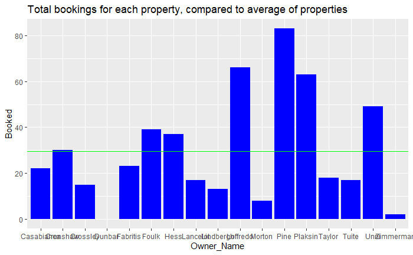

```r
#simple bar graph to look at the number of bookings per property relative to the average number of bookings

Booked_Plot <- New_wide %>%
  ggplot(aes(x = Owner_Name,  y = Booked)) +
  geom_bar(stat = "identity", fill = "blue") +
  geom_hline(aes(yintercept = mean(Booked)), colour = "green") +
  ggtitle("Total bookings for each property, compared to average of properties") + theme_gray()



Booked_Plot
```

[figure not shown]

### What’s going on in the plots?

I chose to plot these graphs seperately because all though they are definitely correlated due to the natural fact that as more people book a property, more people are also going to cancel. But, i thought it would be better to present the number of cancellations seperately so that the home_owner overlook cancellations as an area of improvement just because he has more Bookings.

```r
head(bmre.payments.)
```

|  | ï..RefID | Reservation.ID | Check.In | Check.Out | Number.of.Nights | Payment.Date | Disbursement.Date | Payment.Type | Property.ID | Guest.Name | Payment.Method | Taxable.Revenue | Non.Taxable.Revenue | Tax | Service.Fee | Currency | Paid.By.Guest | Your.Revenue | Payment.Processing.Fee | Stay.Tax.We.Remit | Stay.Tax.You.Remit | Deposit.Amount | Payable.To.You |
| --- | --- | --- | --- | --- | --- | --- | --- | --- | --- | --- | --- | --- | --- | --- | --- | --- | --- | --- | --- | --- | --- | --- | --- |
| 1 | 40259099:47 | HA-5Y7HWR | 27-Jul-18 | 29-Jul-18 | 2 | 30-May-18 | 30-Jul-18 | Rent | 4810284 | Kevin Nguyen | Credit Card | $465.00 | $0.00 | $41.85 | $99.00 | USD | $605.85 | $506.85 | ($15.20) | $0.00 | $0.00 | $491.65 | $491.65 |
| 2 | 8774789:167 | HA-PTMM35 | 26-Jun-18 | 30-Jun-18 | 4 | 27-May-18 | 27-Jun-18 | RDD | 4810284 | Abdul Samad | Credit Card | $780.00 | $300.00 | $70.20 | $89.00 | USD | $1,239.20 | $1,150.20 | ($34.50) | $0.00 | $0.00 | $1,115.70 | $1,115.70 |
| 3 | 6377541:105 | HA-95SC34 | 18-May-18 | 20-May-18 | 2 | 27-May-18 | 21-May-18 | Refund (RDD) | 4810284 | Nestor Nazario | Credit Card | $0.00 | $0.00 | $0.00 | $0.00 | USD | ($300.00) | ($300.00) | $9.00 | $0.00 | $0.00 | ($291.00) | ($291.00) |
| 4 | 8765576:167 | HA-T1GKF7 | 15-Jun-18 | 17-Jun-18 | 2 | 26-May-18 | 18-Jun-18 | RDD | 4810284 | Martine Jean-Baptiste | Credit Card | $530.00 | $300.00 | $47.70 | $59.00 | USD | $936.70 | $877.70 | ($26.33) | $0.00 | $0.00 | $851.37 | $851.37 |
| 5 | 8737385:167 | HA-YTX69Z | 22-Jun-18 | 24-Jun-18 | 2 | 23-May-18 | 25-Jun-18 | RDD | 4810284 | Amanda Hackman | Credit Card | $265.00 | $300.00 | $23.85 | $0.00 | USD | $588.85 | $588.85 | ($17.66) | $0.00 | $0.00 | $571.19 | $571.19 |
| 6 | 8703674:167 | HA-DRS8QS | 8-Jun-18 | 10-Jun-18 | 2 | 20-May-18 | 11-Jun-18 | Rent | 4810284 | indranie sundar | Credit Card | $530.00 | $300.00 | $47.70 | $62.00 | USD | $939.70 | $877.70 | ($26.33) | $0.00 | $0.00 | $851.37 | $851.37 |

```r
nrow(bmre.payments.)
```

```
[1] 208
```

```r
#Joining the reservation data to the payment data by Reservation.ID variable, I then created a filter function to select a specific property.

joint_pay_res <- bmre.payments. %>%
  inner_join(bmre.reservations, by = c("Reservation.ID" = "Reservation.ID")) %>%
  filter(Property.Name == "Pine Swamp - 45 Guest Circle")
```

```
Column `Reservation.ID` joining factors with different levels, coercing to character vector
```

```r
joint_pay_res
```

| ï..RefID | Reservation.ID | Check.In | Check.Out | Number.of.Nights | Payment.Date | Disbursement.Date | Payment.Type | Property.ID | Guest.Name | Payment.Method | Taxable.Revenue | Non.Taxable.Revenue | Tax | Service.Fee | Currency | Paid.By.Guest | Your.Revenue | Payment.Processing.Fee | Stay.Tax.We.Remit | Stay.Tax.You.Remit | Deposit.Amount | Payable.To.You | Listing.Number | Property.Name | Created.On | Email | Inquirer | Phone | Check.in | … |
| --- | --- | --- | --- | --- | --- | --- | --- | --- | --- | --- | --- | --- | --- | --- | --- | --- | --- | --- | --- | --- | --- | --- | --- | --- | --- | --- | --- | --- | --- | --- |
| 40259099:47 | HA-5Y7HWR | 27-Jul-18 | 29-Jul-18 | 2 | 30-May-18 | 30-Jul-18 | Rent | 4810284 | Kevin Nguyen | Credit Card | $465.00 | $0.00 | $41.85 | $99.00 | USD | $605.85 | $506.85 | ($15.20) | $0.00 | $0.00 | $491.65 | $491.65 | 4810284 | Pine Swamp - 45 Guest Circle | 5/31/2018 | kevin.nguyen4110@gmail.com | Kevin Nguyen | +1 (484) 634-6707 | 7/27/2018 | … |
| 8774789:167 | HA-PTMM35 | 26-Jun-18 | 30-Jun-18 | 4 | 27-May-18 | 27-Jun-18 | RDD | 4810284 | Abdul Samad | Credit Card | $780.00 | $300.00 | $70.20 | $89.00 | USD | $1,239.20 | $1,150.20 | ($34.50) | $0.00 | $0.00 | $1,115.70 | $1,115.70 | 4810284 | Pine Swamp - 45 Guest Circle | 5/28/2018 | abdul0smd@outlook.com | Abdul Samad | 13476422255 | 6/26/2018 | … |
| 6377541:105 | HA-95SC34 | 18-May-18 | 20-May-18 | 2 | 27-May-18 | 21-May-18 | Refund (RDD) | 4810284 | Nestor Nazario | Credit Card | $0.00 | $0.00 | $0.00 | $0.00 | USD | ($300.00) | ($300.00) | $9.00 | $0.00 | $0.00 | ($291.00) | ($291.00) | 4810284 | Pine Swamp - 45 Guest Circle | 5/13/2018 | nescnaz@gmail.com | Nestor Nazario | +1 (646) 709-3066 | 5/18/2018 | … |
| 8765576:167 | HA-T1GKF7 | 15-Jun-18 | 17-Jun-18 | 2 | 26-May-18 | 18-Jun-18 | RDD | 4810284 | Martine Jean-Baptiste | Credit Card | $530.00 | $300.00 | $47.70 | $59.00 | USD | $936.70 | $877.70 | ($26.33) | $0.00 | $0.00 | $851.37 | $851.37 | 4810284 | Pine Swamp - 45 Guest Circle | 5/26/2018 | teenimjb@aol.com | Martine Jean-Baptiste | +1 (917) 859-7950 | 6/15/2018 | … |
| 8737385:167 | HA-YTX69Z | 22-Jun-18 | 24-Jun-18 | 2 | 23-May-18 | 25-Jun-18 | RDD | 4810284 | Amanda Hackman | Credit Card | $265.00 | $300.00 | $23.85 | $0.00 | USD | $588.85 | $588.85 | ($17.66) | $0.00 | $0.00 | $571.19 | $571.19 | 4810284 | Pine Swamp - 45 Guest Circle | 5/18/2018 | anmorrisette@gmail.com | Amanda Hackman | +1 (267) 278-8887 | 6/22/2018 | … |
| 8703674:167 | HA-DRS8QS | 8-Jun-18 | 10-Jun-18 | 2 | 20-May-18 | 11-Jun-18 | Rent | 4810284 | indranie sundar | Credit Card | $530.00 | $300.00 | $47.70 | $62.00 | USD | $939.70 | $877.70 | ($26.33) | $0.00 | $0.00 | $851.37 | $851.37 | 4810284 | Pine Swamp - 45 Guest Circle | 5/21/2018 | shivana.sundar@hotmail.com | indranie sundar | +1 (347) 874-4707 | 6/8/2018 | … |
| 6315447:105 | HA-L5Y3X1 | 26-Jul-18 | 29-Jul-18 | 3 | 19-May-18 | 27-Jul-18 | Refund | 4810284 | Jeremy Miloro | Credit Card | $0.00 | $0.00 | $0.00 | $124.00 | USD | ($753.48) | ($629.48) | $18.88 | $0.00 | $0.00 | ($610.60) | ($610.60) | 4810284 | Pine Swamp - 45 Guest Circle | 5/18/2018 | jmiloro13@gmail.com | Jeremy Miloro | +1 (443) 994-2509 | 7/26/2018 | … |
| 39793120:47 | HA-L5Y3X1 | 26-Jul-18 | 29-Jul-18 | 3 | 17-May-18 | 27-Jul-18 | Rent | 4810284 | Jeremy Miloro | Credit Card | $577.50 | $0.00 | $51.98 | $124.00 | USD | $753.48 | $629.48 | ($18.88) | $0.00 | $0.00 | $610.60 | $610.60 | 4810284 | Pine Swamp - 45 Guest Circle | 5/18/2018 | jmiloro13@gmail.com | Jeremy Miloro | +1 (443) 994-2509 | 7/26/2018 | … |
| 39789167:47 | HA-YTX69Z | 22-Jun-18 | 24-Jun-18 | 2 | 17-May-18 | 25-Jun-18 | Rent | 4810284 | Amanda Hackman | Credit Card | $265.00 | $0.00 | $23.85 | $62.00 | USD | $350.85 | $288.85 | ($8.66) | $0.00 | $0.00 | $280.19 | $280.19 | 4810284 | Pine Swamp - 45 Guest Circle | 5/18/2018 | anmorrisette@gmail.com | Amanda Hackman | +1 (267) 278-8887 | 6/22/2018 | … |
| 6269030:105 | HA-NSNZPZ | 4-May-18 | 6-May-18 | 2 | 13-May-18 | 7-May-18 | Refund (RDD) | 4810284 | Robert Frey | Credit Card | $0.00 | $0.00 | $0.00 | $0.00 | USD | ($300.00) | ($300.00) | $9.00 | $0.00 | $0.00 | ($291.00) | ($291.00) | 4810284 | Pine Swamp - 45 Guest Circle | 5/2/2018 | robertfrey2861@icloud.com | Robert Frey | +1 (484) 735-2861 | 5/4/2018 | … |

[output cut: 197 more lines]

```r
#checking to make sure the inner join went smoothly between the reservation and payment data

nrow(joint_pay_res)
```

```
[1] 207
```

```r
glimpse(joint_pay_res)
```

```
Observations: 207
Variables: 37
$ ï..RefID               <fct> 40259099:47, 8774789:167, 6377541:105, 8765576:167, 8737385:167, 8703674:167, 6315447:105, 3979...
$ Reservation.ID         <chr> "HA-5Y7HWR", "HA-PTMM35", "HA-95SC34", "HA-T1GKF7", "HA-YTX69Z", "HA-DRS8QS", "HA-L5Y3X1", "HA-...
$ Check.In               <fct> 27-Jul-18, 26-Jun-18, 18-May-18, 15-Jun-18, 22-Jun-18, 8-Jun-18, 26-Jul-18, 26-Jul-18, 22-Jun-1...
$ Check.Out              <fct> 29-Jul-18, 30-Jun-18, 20-May-18, 17-Jun-18, 24-Jun-18, 10-Jun-18, 29-Jul-18, 29-Jul-18, 24-Jun-...
$ Number.of.Nights       <int> 2, 4, 2, 2, 2, 2, 3, 3, 2, 2, 2, 3, 2, 6, 3, 3, 2, 2, 2, 3, 3, 7, 3, 3, 3, 2, 2, 2, 2, 2, 3, 3,...
$ Payment.Date           <fct> 30-May-18, 27-May-18, 27-May-18, 26-May-18, 23-May-18, 20-May-18, 19-May-18, 17-May-18, 17-May-...
$ Disbursement.Date      <fct> 30-Jul-18, 27-Jun-18, 21-May-18, 18-Jun-18, 25-Jun-18, 11-Jun-18, 27-Jul-18, 27-Jul-18, 25-Jun-...
$ Payment.Type           <fct> Rent, RDD, Refund (RDD), RDD, RDD, Rent, Refund, Rent, Rent, Refund (RDD), RDD, RDD, RDD, Rent,...
$ Property.ID            <int> 4810284, 4810284, 4810284, 4810284, 4810284, 4810284, 4810284, 4810284, 4810284, 4810284, 48102...
$ Guest.Name             <fct> Kevin Nguyen, Abdul Samad, Nestor Nazario, Martine Jean-Baptiste, Amanda Hackman, indranie sund...
$ Payment.Method         <fct> Credit Card, Credit Card, Credit Card, Credit Card, Credit Card, Credit Card, Credit Card, Cred...
$ Taxable.Revenue        <fct> "$465.00 ", "$780.00 ", "$0.00 ", "$530.00 ", "$265.00 ", "$530.00 ", "$0.00 ", "$577.50 ", "$2...
$ Non.Taxable.Revenue    <fct> "$0.00 ", "$300.00 ", "$0.00 ", "$300.00 ", "$300.00 ", "$300.00 ", "$0.00 ", "$0.00 ", "$0.00 ...
```

[output cut: 24 more lines]

```r
#Cleaning up the data, by using regular expressions as well as date functions to remove extra characters in profit, get the dates in the correct format, and to select the variables I wish to analyze. I also calculated the ratio of children to adults in order to use that in my analysis.

Cleaned <- joint_pay_res %>%
  mutate(
    Check_in = mdy(Check.in), Check_out =  mdy(Check.out),
    Profit = as.numeric(gsub("[\\$, \\($)]", "",Payable.To.You)),
    ServiceFee = as.numeric(gsub("[\\$, \\($)]", "",Service.Fee)),
    month = lubridate::month(Check_in),
    TA = (Adults),
    TC = (Children),
    Child_ratio = round((TC/(TA + TC)), digits = 2)
    ) %>%
  select(month, Check_in, Check_out, Nights.Stay, Adults, Children, Child_ratio, Payment.Type, Phone, Status, Profit, ServiceFee)

Cleaned
```

| month | Check_in | Check_out | Nights.Stay | Adults | Children | Child_ratio | Payment.Type | Phone | Status | Profit | ServiceFee |
| --- | --- | --- | --- | --- | --- | --- | --- | --- | --- | --- | --- |
| 7 | 2018-07-27 | 2018-07-29 | 2 | 8 | 0 | 0.00 | Rent | +1 (484) 634-6707 | Booked | 491.65 | 99 |
| 6 | 2018-06-26 | 2018-06-30 | 4 | 6 | 4 | 0.40 | RDD | 13476422255 | Booked | 1115.70 | 89 |
| 5 | 2018-05-18 | 2018-05-20 | 2 | 8 | 3 | 0.27 | Refund (RDD) | +1 (646) 709-3066 | Booked | 291.00 | 0 |
| 6 | 2018-06-15 | 2018-06-17 | 2 | 5 | 2 | 0.29 | RDD | +1 (917) 859-7950 | Booked | 851.37 | 59 |
| 6 | 2018-06-22 | 2018-06-24 | 2 | 12 | 0 | 0.00 | RDD | +1 (267) 278-8887 | Booked | 571.19 | 0 |
| 6 | 2018-06-08 | 2018-06-10 | 2 | 2 | 8 | 0.80 | Rent | +1 (347) 874-4707 | Booked | 851.37 | 62 |
| 7 | 2018-07-26 | 2018-07-29 | 3 | 8 | 0 | 0.00 | Refund | +1 (443) 994-2509 | Cancelled | 610.60 | 124 |
| 7 | 2018-07-26 | 2018-07-29 | 3 | 8 | 0 | 0.00 | Rent | +1 (443) 994-2509 | Cancelled | 610.60 | 124 |
| 6 | 2018-06-22 | 2018-06-24 | 2 | 12 | 0 | 0.00 | Rent | +1 (267) 278-8887 | Booked | 280.19 | 62 |
| 5 | 2018-05-04 | 2018-05-06 | 2 | 2 | 3 | 0.60 | Refund (RDD) | +1 (484) 735-2861 | Booked | 291.00 | 0 |

[output cut: 197 more lines]

```r
#Finding total profit for each length of stay.

Profits_per_night <- Cleaned %>%
  group_by(Nights= as.factor(Nights.Stay)) %>%
  summarise(Total_profit = sum(Profit))

Profits_per_night
```

| Nights | Total_profit |
| --- | --- |
| 1 | 602.66 |
| 2 | 56827.24 |
| 3 | 42888.88 |
| 4 | 7434.76 |
| 5 | 8274.32 |
| 6 | 4641.19 |
| 7 | 11870.86 |

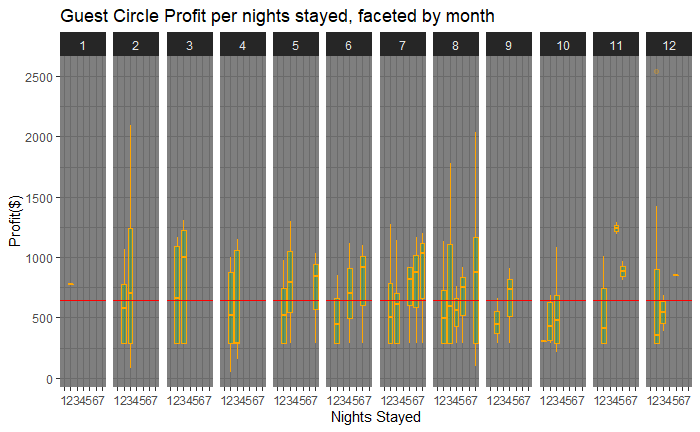

```r
#Plotting to see if their is a difference in profits over different months and length of stay, I also input a horizontal average for profit to give a measurement across the whole year.

Profit_boxplot<- Cleaned %>%
  ggplot(aes(x = as.factor(Nights.Stay), y = Profit)) +
  geom_boxplot(aes(y = Profit), color="orange", fill="green", alpha=0.2) +
  xlab("Nights Stayed") + ylab("Profit($)") +ggtitle("Guest Circle Profit per nights stayed, faceted by month") +
  facet_grid(.~month)+ geom_hline(aes(yintercept = mean(Profit)), color = "red") +
  theme_dark()

Profit_boxplot
```

### What does this plot say?

[figure not shown]

### Messy plot with interesting patterns.

This plot is extremely useful in telling some secrets about the business and addressing our research question. One thing that sticks out first is of the obvious lack of children between 7.18 and 1.19 this would be a great finding to discuss with the homeowner and inquire about what happened. I also find the payment type to be useful. The most profit comes from RDD payments and the least comes from a charge when refunding to people who cancel. Although messy, this plot has some interesting characteristics that I believe could be a good program to run on property data in order to get a quick summary of their history in a compact form.